# Optimal Treatment Analysis

## Outcome Variable

**Outcome Variable:** ever_stunted

## Predictor Variables

**Intervention Variable:** hdlvry

**Adjustment Set:**

- arm
- sex
- W_mage
- meducyrs
- feducyrs
- hhwealth_quart
- W_nrooms
- brthmon
- W_parity
- impsan
- delta_W_mage
- delta_meducyrs
- delta_feducyrs
- delta_hhwealth_quart
- delta_W_nrooms
- delta_brthmon
- delta_W_parity
- delta_impsan

## Stratifying Variables

The analysis was stratified on these variable(s):

- agecat
- studyid
- country

## Data Summary

| agecat | studyid | country | hdlvry | ever_stunted | n_cell | n |
| --- | --- | --- | --- | --- | --- | --- |
| 0-24 months (no birth st.) | ki1000108-CMC-V-BCS-2002 | INDIA | 0 | 0 | 27 | 293 |
| 0-24 months (no birth st.) | ki1000108-CMC-V-BCS-2002 | INDIA | 0 | 1 | 260 | 293 |
| 0-24 months (no birth st.) | ki1000108-CMC-V-BCS-2002 | INDIA | 1 | 0 | 1 | 293 |
| 0-24 months (no birth st.) | ki1000108-CMC-V-BCS-2002 | INDIA | 1 | 1 | 5 | 293 |
| 0-24 months (no birth st.) | ki1000108-IRC | INDIA | 0 | 0 | 145 | 360 |
| 0-24 months (no birth st.) | ki1000108-IRC | INDIA | 0 | 1 | 208 | 360 |
| 0-24 months (no birth st.) | ki1000108-IRC | INDIA | 1 | 0 | 2 | 360 |
| 0-24 months (no birth st.) | ki1000108-IRC | INDIA | 1 | 1 | 5 | 360 |
| 0-24 months (no birth st.) | ki1000109-EE | PAKISTAN | 0 | 0 | 25 | 247 |
| 0-24 months (no birth st.) | ki1000109-EE | PAKISTAN | 0 | 1 | 137 | 247 |
| 0-24 months (no birth st.) | ki1000109-EE | PAKISTAN | 1 | 0 | 8 | 247 |
| 0-24 months (no birth st.) | ki1000109-EE | PAKISTAN | 1 | 1 | 77 | 247 |
| 0-24 months (no birth st.) | ki1000304b-SAS-CompFeed | INDIA | 0 | 0 | 57 | 887 |
| 0-24 months (no birth st.) | ki1000304b-SAS-CompFeed | INDIA | 0 | 1 | 56 | 887 |
| 0-24 months (no birth st.) | ki1000304b-SAS-CompFeed | INDIA | 1 | 0 | 296 | 887 |
| 0-24 months (no birth st.) | ki1000304b-SAS-CompFeed | INDIA | 1 | 1 | 478 | 887 |
| 0-24 months (no birth st.) | ki1000304b-SAS-FoodSuppl | INDIA | 0 | 0 | 18 | 257 |
| 0-24 months (no birth st.) | ki1000304b-SAS-FoodSuppl | INDIA | 0 | 1 | 40 | 257 |
| 0-24 months (no birth st.) | ki1000304b-SAS-FoodSuppl | INDIA | 1 | 0 | 54 | 257 |
| 0-24 months (no birth st.) | ki1000304b-SAS-FoodSuppl | INDIA | 1 | 1 | 145 | 257 |
| 0-24 months (no birth st.) | ki1017093b-PROVIDE | BANGLADESH | 0 | 0 | 299 | 634 |
| 0-24 months (no birth st.) | ki1017093b-PROVIDE | BANGLADESH | 0 | 1 | 170 | 634 |
| 0-24 months (no birth st.) | ki1017093b-PROVIDE | BANGLADESH | 1 | 0 | 97 | 634 |
| 0-24 months (no birth st.) | ki1017093b-PROVIDE | BANGLADESH | 1 | 1 | 68 | 634 |
| 0-24 months (no birth st.) | ki1017093c-NIH-Crypto | BANGLADESH | 0 | 0 | 320 | 653 |
| 0-24 months (no birth st.) | ki1017093c-NIH-Crypto | BANGLADESH | 0 | 1 | 194 | 653 |
| 0-24 months (no birth st.) | ki1017093c-NIH-Crypto | BANGLADESH | 1 | 0 | 76 | 653 |
| 0-24 months (no birth st.) | ki1017093c-NIH-Crypto | BANGLADESH | 1 | 1 | 63 | 653 |
| 0-24 months (no birth st.) | ki1066203-TanzaniaChild2 | TANZANIA, UNITED REPUBLIC OF | 0 | 0 | 1465 | 2129 |
| 0-24 months (no birth st.) | ki1066203-TanzaniaChild2 | TANZANIA, UNITED REPUBLIC OF | 0 | 1 | 626 | 2129 |

[output cut: 114 more lines]

The following strata were considered:

- agecat: 0-24 months (no birth st.), studyid: ki1000108-CMC-V-BCS-2002, country: INDIA
- agecat: 0-24 months (no birth st.), studyid: ki1000108-IRC, country: INDIA
- agecat: 0-24 months (no birth st.), studyid: ki1000109-EE, country: PAKISTAN
- agecat: 0-24 months (no birth st.), studyid: ki1000304b-SAS-CompFeed, country: INDIA
- agecat: 0-24 months (no birth st.), studyid: ki1000304b-SAS-FoodSuppl, country: INDIA
- agecat: 0-24 months (no birth st.), studyid: ki1017093b-PROVIDE, country: BANGLADESH
- agecat: 0-24 months (no birth st.), studyid: ki1017093c-NIH-Crypto, country: BANGLADESH
- agecat: 0-24 months (no birth st.), studyid: ki1066203-TanzaniaChild2, country: TANZANIA, UNITED REPUBLIC OF
- agecat: 0-24 months (no birth st.), studyid: ki1113344-GMS-Nepal, country: NEPAL
- agecat: 0-24 months (no birth st.), studyid: ki1135781-COHORTS, country: INDIA
- agecat: 0-24 months (no birth st.), studyid: kiGH5241-JiVitA-3, country: BANGLADESH
- agecat: 0-24 months (no birth st.), studyid: kiGH5241-JiVitA-4, country: BANGLADESH
- agecat: 0-6 months (no birth st.), studyid: ki1000108-CMC-V-BCS-2002, country: INDIA
- agecat: 0-6 months (no birth st.), studyid: ki1000108-IRC, country: INDIA
- agecat: 0-6 months (no birth st.), studyid: ki1000109-EE, country: PAKISTAN
- agecat: 0-6 months (no birth st.), studyid: ki1000304b-SAS-CompFeed, country: INDIA
- agecat: 0-6 months (no birth st.), studyid: ki1000304b-SAS-FoodSuppl, country: INDIA
- agecat: 0-6 months (no birth st.), studyid: ki1017093b-PROVIDE, country: BANGLADESH
- agecat: 0-6 months (no birth st.), studyid: ki1017093c-NIH-Crypto, country: BANGLADESH
- agecat: 0-6 months (no birth st.), studyid: ki1066203-TanzaniaChild2, country: TANZANIA, UNITED REPUBLIC OF
- agecat: 0-6 months (no birth st.), studyid: ki1113344-GMS-Nepal, country: NEPAL
- agecat: 0-6 months (no birth st.), studyid: ki1135781-COHORTS, country: INDIA
- agecat: 0-6 months (no birth st.), studyid: kiGH5241-JiVitA-3, country: BANGLADESH
- agecat: 0-6 months (no birth st.), studyid: kiGH5241-JiVitA-4, country: BANGLADESH
- agecat: 6-24 months, studyid: ki1000108-CMC-V-BCS-2002, country: INDIA
- agecat: 6-24 months, studyid: ki1000108-IRC, country: INDIA
- agecat: 6-24 months, studyid: ki1000109-EE, country: PAKISTAN
- agecat: 6-24 months, studyid: ki1000304b-SAS-CompFeed, country: INDIA
- agecat: 6-24 months, studyid: ki1000304b-SAS-FoodSuppl, country: INDIA
- agecat: 6-24 months, studyid: ki1017093b-PROVIDE, country: BANGLADESH
- agecat: 6-24 months, studyid: ki1017093c-NIH-Crypto, country: BANGLADESH
- agecat: 6-24 months, studyid: ki1066203-TanzaniaChild2, country: TANZANIA, UNITED REPUBLIC OF
- agecat: 6-24 months, studyid: ki1113344-GMS-Nepal, country: NEPAL
- agecat: 6-24 months, studyid: ki1135781-COHORTS, country: INDIA
- agecat: 6-24 months, studyid: kiGH5241-JiVitA-3, country: BANGLADESH
- agecat: 6-24 months, studyid: kiGH5241-JiVitA-4, country: BANGLADESH

### Dropped Strata

Some strata were dropped due to rare outcomes:

- agecat: 0-24 months (no birth st.), studyid: ki1000108-CMC-V-BCS-2002, country: INDIA
- agecat: 0-24 months (no birth st.), studyid: ki1000108-IRC, country: INDIA
- agecat: 0-6 months (no birth st.), studyid: ki1000108-CMC-V-BCS-2002, country: INDIA
- agecat: 0-6 months (no birth st.), studyid: ki1000108-IRC, country: INDIA
- agecat: 0-6 months (no birth st.), studyid: ki1000304b-SAS-FoodSuppl, country: INDIA
- agecat: 0-6 months (no birth st.), studyid: kiGH5241-JiVitA-3, country: BANGLADESH
- agecat: 6-24 months, studyid: ki1000108-CMC-V-BCS-2002, country: INDIA
- agecat: 6-24 months, studyid: ki1000108-IRC, country: INDIA

## Methods Detail

We’re interested in the causal parameters $E[Y_a]$ for all values of $a \in \mathcal{A}$. These parameters represent the mean outcome if, possibly contrary to fact, we intervened to set all units to have $A=a$. Under the randomization and positivity assumptions, these are identified by the statistical parameters $\psi_a=E_W[E_{Y|A,W}(Y|A=a,W)]$. In addition, we’re interested in the mean of $Y$, $E[Y]$ under no intervention (the observed mean). We will estimate these parameters by using SuperLearner to fit the relevant likelihood factors – $E_{Y|A,W}(Y|A=a,W)$ and $p(A=a|W)$, and then updating our likelihood fit using a joint TMLE.

For unadjusted analyses ($W=\{\}$), initial likelihoods were estimated using Lrnr_glm to estimate the simple $E(Y|A)$ and Lrnr_mean to estimate $p(A)$. For adjusted analyses, a small library containing Lrnr_glmnet, Lrnr_xgboost, and Lrnr_mean was used.

Having estimated these parameters, we will then use the delta method to estimate relative risks and attributable risks relative to a prespecified baseline level of $A$.

# Results Detail

## Results Plots

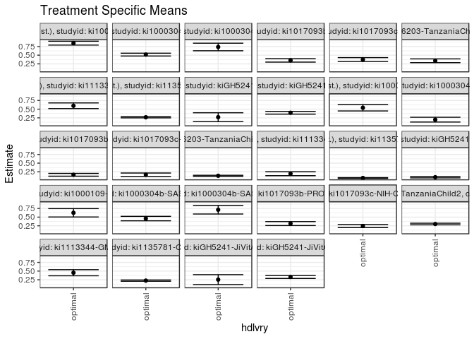

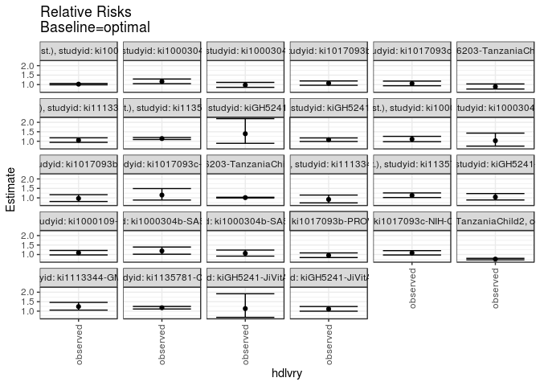

## Results Table

### Parameter: TSM

| agecat | studyid | country | intervention_level | baseline_level | estimate | ci_lower | ci_upper |
| --- | --- | --- | --- | --- | --- | --- | --- |
| 0-24 months (no birth st.) | ki1000109-EE | PAKISTAN | optimal | NA | 0.8465559 | 0.7906486 | 0.9024632 |
| 0-24 months (no birth st.) | ki1000304b-SAS-CompFeed | INDIA | optimal | NA | 0.5167389 | 0.4759724 | 0.5575054 |
| 0-24 months (no birth st.) | ki1000304b-SAS-FoodSuppl | INDIA | optimal | NA | 0.7365598 | 0.6272487 | 0.8458709 |
| 0-24 months (no birth st.) | ki1017093b-PROVIDE | BANGLADESH | optimal | NA | 0.3501361 | 0.3001526 | 0.4001196 |
| 0-24 months (no birth st.) | ki1017093c-NIH-Crypto | BANGLADESH | optimal | NA | 0.3731616 | 0.3172272 | 0.4290960 |
| 0-24 months (no birth st.) | ki1066203-TanzaniaChild2 | TANZANIA, UNITED REPUBLIC OF | optimal | NA | 0.3383556 | 0.2836137 | 0.3930976 |
| 0-24 months (no birth st.) | ki1113344-GMS-Nepal | NEPAL | optimal | NA | 0.5980309 | 0.5164847 | 0.6795771 |
| 0-24 months (no birth st.) | ki1135781-COHORTS | INDIA | optimal | NA | 0.2660578 | 0.2485554 | 0.2835603 |
| 0-24 months (no birth st.) | kiGH5241-JiVitA-3 | BANGLADESH | optimal | NA | 0.2682685 | 0.1403588 | 0.3961781 |
| 0-24 months (no birth st.) | kiGH5241-JiVitA-4 | BANGLADESH | optimal | NA | 0.3962344 | 0.3564339 | 0.4360348 |
| 0-6 months (no birth st.) | ki1000109-EE | PAKISTAN | optimal | NA | 0.5403238 | 0.4484827 | 0.6321648 |
| 0-6 months (no birth st.) | ki1000304b-SAS-CompFeed | INDIA | optimal | NA | 0.1971949 | 0.1283003 | 0.2660895 |
| 0-6 months (no birth st.) | ki1017093b-PROVIDE | BANGLADESH | optimal | NA | 0.1638228 | 0.1238419 | 0.2038036 |
| 0-6 months (no birth st.) | ki1017093c-NIH-Crypto | BANGLADESH | optimal | NA | 0.1653087 | 0.1158578 | 0.2147597 |
| 0-6 months (no birth st.) | ki1066203-TanzaniaChild2 | TANZANIA, UNITED REPUBLIC OF | optimal | NA | 0.1358275 | 0.1210317 | 0.1506233 |
| 0-6 months (no birth st.) | ki1113344-GMS-Nepal | NEPAL | optimal | NA | 0.1944047 | 0.1374560 | 0.2513535 |
| 0-6 months (no birth st.) | ki1135781-COHORTS | INDIA | optimal | NA | 0.0717460 | 0.0611790 | 0.0823129 |
| 0-6 months (no birth st.) | kiGH5241-JiVitA-4 | BANGLADESH | optimal | NA | 0.0937276 | 0.0738017 | 0.1136535 |
| 6-24 months | ki1000109-EE | PAKISTAN | optimal | NA | 0.6244512 | 0.5035728 | 0.7453295 |
| 6-24 months | ki1000304b-SAS-CompFeed | INDIA | optimal | NA | 0.4582813 | 0.3942403 | 0.5223223 |
| 6-24 months | ki1000304b-SAS-FoodSuppl | INDIA | optimal | NA | 0.7127872 | 0.5897830 | 0.8357914 |
| 6-24 months | ki1017093b-PROVIDE | BANGLADESH | optimal | NA | 0.3140136 | 0.2570294 | 0.3709978 |
| 6-24 months | ki1017093c-NIH-Crypto | BANGLADESH | optimal | NA | 0.2425959 | 0.1974812 | 0.2877106 |
| 6-24 months | ki1066203-TanzaniaChild2 | TANZANIA, UNITED REPUBLIC OF | optimal | NA | 0.3012869 | 0.2777623 | 0.3248115 |
| 6-24 months | ki1113344-GMS-Nepal | NEPAL | optimal | NA | 0.4529149 | 0.3646549 | 0.5411749 |
| 6-24 months | ki1135781-COHORTS | INDIA | optimal | NA | 0.2256163 | 0.2077400 | 0.2434925 |
| 6-24 months | kiGH5241-JiVitA-3 | BANGLADESH | optimal | NA | 0.2548028 | 0.1125625 | 0.3970431 |
| 6-24 months | kiGH5241-JiVitA-4 | BANGLADESH | optimal | NA | 0.3299644 | 0.2880853 | 0.3718434 |

### Parameter: E(Y)

| agecat | studyid | country | intervention_level | baseline_level | estimate | ci_lower | ci_upper |
| --- | --- | --- | --- | --- | --- | --- | --- |
| 0-24 months (no birth st.) | ki1000109-EE | PAKISTAN | observed | NA | 0.8663968 | 0.8238812 | 0.9089123 |
| 0-24 months (no birth st.) | ki1000304b-SAS-CompFeed | INDIA | observed | NA | 0.6020293 | 0.5512634 | 0.6527952 |
| 0-24 months (no birth st.) | ki1000304b-SAS-FoodSuppl | INDIA | observed | NA | 0.7198444 | 0.6648337 | 0.7748550 |
| 0-24 months (no birth st.) | ki1017093b-PROVIDE | BANGLADESH | observed | NA | 0.3753943 | 0.3376725 | 0.4131162 |
| 0-24 months (no birth st.) | ki1017093c-NIH-Crypto | BANGLADESH | observed | NA | 0.3935681 | 0.3560687 | 0.4310676 |
| 0-24 months (no birth st.) | ki1066203-TanzaniaChild2 | TANZANIA, UNITED REPUBLIC OF | observed | NA | 0.3010803 | 0.2815901 | 0.3205706 |
| 0-24 months (no birth st.) | ki1113344-GMS-Nepal | NEPAL | observed | NA | 0.6305221 | 0.5880881 | 0.6729561 |
| 0-24 months (no birth st.) | ki1135781-COHORTS | INDIA | observed | NA | 0.3036392 | 0.2901712 | 0.3171072 |
| 0-24 months (no birth st.) | kiGH5241-JiVitA-3 | BANGLADESH | observed | NA | 0.3745174 | 0.3090067 | 0.4400281 |
| 0-24 months (no birth st.) | kiGH5241-JiVitA-4 | BANGLADESH | observed | NA | 0.4273638 | 0.4069167 | 0.4478110 |
| 0-6 months (no birth st.) | ki1000109-EE | PAKISTAN | observed | NA | 0.5991903 | 0.5379507 | 0.6604298 |
| 0-6 months (no birth st.) | ki1000304b-SAS-CompFeed | INDIA | observed | NA | 0.2029312 | 0.1748514 | 0.2310111 |
| 0-6 months (no birth st.) | ki1017093b-PROVIDE | BANGLADESH | observed | NA | 0.1593060 | 0.1307970 | 0.1878149 |
| 0-6 months (no birth st.) | ki1017093c-NIH-Crypto | BANGLADESH | observed | NA | 0.1898928 | 0.1597870 | 0.2199986 |
| 0-6 months (no birth st.) | ki1066203-TanzaniaChild2 | TANZANIA, UNITED REPUBLIC OF | observed | NA | 0.1376233 | 0.1229861 | 0.1522605 |
| 0-6 months (no birth st.) | ki1113344-GMS-Nepal | NEPAL | observed | NA | 0.1787149 | 0.1450329 | 0.2123968 |
| 0-6 months (no birth st.) | ki1135781-COHORTS | INDIA | observed | NA | 0.0812729 | 0.0731685 | 0.0893773 |
| 0-6 months (no birth st.) | kiGH5241-JiVitA-4 | BANGLADESH | observed | NA | 0.0979284 | 0.0852731 | 0.1105838 |
| 6-24 months | ki1000109-EE | PAKISTAN | observed | NA | 0.6804124 | 0.5871313 | 0.7736934 |
| 6-24 months | ki1000304b-SAS-CompFeed | INDIA | observed | NA | 0.5451761 | 0.5131549 | 0.5771973 |
| 6-24 months | ki1000304b-SAS-FoodSuppl | INDIA | observed | NA | 0.7572016 | 0.7031798 | 0.8112234 |
| 6-24 months | ki1017093b-PROVIDE | BANGLADESH | observed | NA | 0.2997812 | 0.2577294 | 0.3418330 |
| 6-24 months | ki1017093c-NIH-Crypto | BANGLADESH | observed | NA | 0.2628458 | 0.2244546 | 0.3012371 |
| 6-24 months | ki1066203-TanzaniaChild2 | TANZANIA, UNITED REPUBLIC OF | observed | NA | 0.2281967 | 0.2071268 | 0.2492667 |
| 6-24 months | ki1113344-GMS-Nepal | NEPAL | observed | NA | 0.5625000 | 0.5138243 | 0.6111757 |
| 6-24 months | ki1135781-COHORTS | INDIA | observed | NA | 0.2661332 | 0.2522150 | 0.2800514 |
| 6-24 months | kiGH5241-JiVitA-3 | BANGLADESH | observed | NA | 0.2889908 | 0.2220207 | 0.3559610 |
| 6-24 months | kiGH5241-JiVitA-4 | BANGLADESH | observed | NA | 0.3675807 | 0.3466082 | 0.3885532 |

### Parameter: RR

| agecat | studyid | country | intervention_level | baseline_level | estimate | ci_lower | ci_upper |
| --- | --- | --- | --- | --- | --- | --- | --- |
| 0-24 months (no birth st.) | ki1000109-EE | PAKISTAN | observed | optimal | 1.0234371 | 0.9886448 | 1.0594539 |
| 0-24 months (no birth st.) | ki1000304b-SAS-CompFeed | INDIA | observed | optimal | 1.1650551 | 1.0481811 | 1.2949607 |
| 0-24 months (no birth st.) | ki1000304b-SAS-FoodSuppl | INDIA | observed | optimal | 0.9773061 | 0.8555884 | 1.1163395 |
| 0-24 months (no birth st.) | ki1017093b-PROVIDE | BANGLADESH | observed | optimal | 1.0721382 | 0.9637353 | 1.1927344 |
| 0-24 months (no birth st.) | ki1017093c-NIH-Crypto | BANGLADESH | observed | optimal | 1.0546855 | 0.9397257 | 1.1837088 |
| 0-24 months (no birth st.) | ki1066203-TanzaniaChild2 | TANZANIA, UNITED REPUBLIC OF | observed | optimal | 0.8898339 | 0.7659482 | 1.0337572 |
| 0-24 months (no birth st.) | ki1113344-GMS-Nepal | NEPAL | observed | optimal | 1.0543303 | 0.9418085 | 1.1802955 |
| 0-24 months (no birth st.) | ki1135781-COHORTS | INDIA | observed | optimal | 1.1412526 | 1.0899791 | 1.1949381 |
| 0-24 months (no birth st.) | kiGH5241-JiVitA-3 | BANGLADESH | observed | optimal | 1.3960545 | 0.8886614 | 2.1931505 |
| 0-24 months (no birth st.) | kiGH5241-JiVitA-4 | BANGLADESH | observed | optimal | 1.0785632 | 0.9891076 | 1.1761091 |
| 0-6 months (no birth st.) | ki1000109-EE | PAKISTAN | observed | optimal | 1.1089468 | 0.9779622 | 1.2574749 |
| 0-6 months (no birth st.) | ki1000304b-SAS-CompFeed | INDIA | observed | optimal | 1.0290899 | 0.7414527 | 1.4283121 |
| 0-6 months (no birth st.) | ki1017093b-PROVIDE | BANGLADESH | observed | optimal | 0.9724289 | 0.8093915 | 1.1683074 |
| 0-6 months (no birth st.) | ki1017093c-NIH-Crypto | BANGLADESH | observed | optimal | 1.1487161 | 0.8856225 | 1.4899674 |
| 0-6 months (no birth st.) | ki1066203-TanzaniaChild2 | TANZANIA, UNITED REPUBLIC OF | observed | optimal | 1.0132213 | 0.9946578 | 1.0321313 |
| 0-6 months (no birth st.) | ki1113344-GMS-Nepal | NEPAL | observed | optimal | 0.9192927 | 0.7355666 | 1.1489089 |
| 0-6 months (no birth st.) | ki1135781-COHORTS | INDIA | observed | optimal | 1.1327872 | 1.0174838 | 1.2611570 |
| 0-6 months (no birth st.) | kiGH5241-JiVitA-4 | BANGLADESH | observed | optimal | 1.0448198 | 0.8893463 | 1.2274729 |
| 6-24 months | ki1000109-EE | PAKISTAN | observed | optimal | 1.0896166 | 0.9784310 | 1.2134370 |
| 6-24 months | ki1000304b-SAS-CompFeed | INDIA | observed | optimal | 1.1896102 | 1.0150123 | 1.3942415 |
| 6-24 months | ki1000304b-SAS-FoodSuppl | INDIA | observed | optimal | 1.0623109 | 0.9138081 | 1.2349470 |
| 6-24 months | ki1017093b-PROVIDE | BANGLADESH | observed | optimal | 0.9546758 | 0.8398465 | 1.0852052 |
| 6-24 months | ki1017093c-NIH-Crypto | BANGLADESH | observed | optimal | 1.0834721 | 0.9755855 | 1.2032895 |
| 6-24 months | ki1066203-TanzaniaChild2 | TANZANIA, UNITED REPUBLIC OF | observed | optimal | 0.7574067 | 0.7191700 | 0.7976765 |
| 6-24 months | ki1113344-GMS-Nepal | NEPAL | observed | optimal | 1.2419551 | 1.0544550 | 1.4627958 |
| 6-24 months | ki1135781-COHORTS | INDIA | observed | optimal | 1.1795834 | 1.1146509 | 1.2482985 |
| 6-24 months | kiGH5241-JiVitA-3 | BANGLADESH | observed | optimal | 1.1341743 | 0.6707590 | 1.9177549 |
| 6-24 months | kiGH5241-JiVitA-4 | BANGLADESH | observed | optimal | 1.1140011 | 0.9977851 | 1.2437534 |

### Parameter: PAR

| agecat | studyid | country | intervention_level | baseline_level | estimate | ci_lower | ci_upper |
| --- | --- | --- | --- | --- | --- | --- | --- |
| 0-24 months (no birth st.) | ki1000109-EE | PAKISTAN | optimal | NA | 0.0198408 | -0.0092372 | 0.0489189 |
| 0-24 months (no birth st.) | ki1000304b-SAS-CompFeed | INDIA | optimal | NA | 0.0852904 | 0.0255638 | 0.1450170 |
| 0-24 months (no birth st.) | ki1000304b-SAS-FoodSuppl | INDIA | optimal | NA | -0.0167154 | -0.1145992 | 0.0811683 |
| 0-24 months (no birth st.) | ki1017093b-PROVIDE | BANGLADESH | optimal | NA | 0.0252582 | -0.0122778 | 0.0627942 |
| 0-24 months (no birth st.) | ki1017093c-NIH-Crypto | BANGLADESH | optimal | NA | 0.0204065 | -0.0226977 | 0.0635107 |
| 0-24 months (no birth st.) | ki1066203-TanzaniaChild2 | TANZANIA, UNITED REPUBLIC OF | optimal | NA | -0.0372753 | -0.0879980 | 0.0134474 |
| 0-24 months (no birth st.) | ki1113344-GMS-Nepal | NEPAL | optimal | NA | 0.0324912 | -0.0348463 | 0.0998286 |
| 0-24 months (no birth st.) | ki1135781-COHORTS | INDIA | optimal | NA | 0.0375814 | 0.0253387 | 0.0498241 |
| 0-24 months (no birth st.) | kiGH5241-JiVitA-3 | BANGLADESH | optimal | NA | 0.1062489 | -0.0171859 | 0.2296837 |
| 0-24 months (no birth st.) | kiGH5241-JiVitA-4 | BANGLADESH | optimal | NA | 0.0311294 | -0.0031550 | 0.0654138 |
| 0-6 months (no birth st.) | ki1000109-EE | PAKISTAN | optimal | NA | 0.0588665 | -0.0086953 | 0.1264284 |
| 0-6 months (no birth st.) | ki1000304b-SAS-CompFeed | INDIA | optimal | NA | 0.0057364 | -0.0589524 | 0.0704252 |
| 0-6 months (no birth st.) | ki1017093b-PROVIDE | BANGLADESH | optimal | NA | -0.0045168 | -0.0345158 | 0.0254822 |
| 0-6 months (no birth st.) | ki1017093c-NIH-Crypto | BANGLADESH | optimal | NA | 0.0245841 | -0.0187459 | 0.0679140 |
| 0-6 months (no birth st.) | ki1066203-TanzaniaChild2 | TANZANIA, UNITED REPUBLIC OF | optimal | NA | 0.0017958 | -0.0007127 | 0.0043044 |
| 0-6 months (no birth st.) | ki1113344-GMS-Nepal | NEPAL | optimal | NA | -0.0156899 | -0.0591562 | 0.0277764 |
| 0-6 months (no birth st.) | ki1135781-COHORTS | INDIA | optimal | NA | 0.0095269 | 0.0017767 | 0.0172772 |
| 0-6 months (no birth st.) | kiGH5241-JiVitA-4 | BANGLADESH | optimal | NA | 0.0042009 | -0.0108765 | 0.0192782 |
| 6-24 months | ki1000109-EE | PAKISTAN | optimal | NA | 0.0559612 | -0.0098282 | 0.1217506 |
| 6-24 months | ki1000304b-SAS-CompFeed | INDIA | optimal | NA | 0.0868948 | 0.0115273 | 0.1622623 |
| 6-24 months | ki1000304b-SAS-FoodSuppl | INDIA | optimal | NA | 0.0444144 | -0.0626674 | 0.1514962 |
| 6-24 months | ki1017093b-PROVIDE | BANGLADESH | optimal | NA | -0.0142324 | -0.0543475 | 0.0258826 |
| 6-24 months | ki1017093c-NIH-Crypto | BANGLADESH | optimal | NA | 0.0202500 | -0.0051503 | 0.0456502 |
| 6-24 months | ki1066203-TanzaniaChild2 | TANZANIA, UNITED REPUBLIC OF | optimal | NA | -0.0730902 | -0.0863777 | -0.0598026 |
| 6-24 months | ki1113344-GMS-Nepal | NEPAL | optimal | NA | 0.1095851 | 0.0360950 | 0.1830752 |
| 6-24 months | ki1135781-COHORTS | INDIA | optimal | NA | 0.0405169 | 0.0276875 | 0.0533464 |
| 6-24 months | kiGH5241-JiVitA-3 | BANGLADESH | optimal | NA | 0.0341880 | -0.1004638 | 0.1688398 |
| 6-24 months | kiGH5241-JiVitA-4 | BANGLADESH | optimal | NA | 0.0376163 | 0.0013210 | 0.0739116 |

### Parameter: PAF

| agecat | studyid | country | intervention_level | baseline_level | estimate | ci_lower | ci_upper |
| --- | --- | --- | --- | --- | --- | --- | --- |
| 0-24 months (no birth st.) | ki1000109-EE | PAKISTAN | optimal | NA | 0.0229004 | -0.0114856 | 0.0561175 |
| 0-24 months (no birth st.) | ki1000304b-SAS-CompFeed | INDIA | optimal | NA | 0.1416715 | 0.0459664 | 0.2277758 |
| 0-24 months (no birth st.) | ki1000304b-SAS-FoodSuppl | INDIA | optimal | NA | -0.0232209 | -0.1687863 | 0.1042152 |
| 0-24 months (no birth st.) | ki1017093b-PROVIDE | BANGLADESH | optimal | NA | 0.0672844 | -0.0376293 | 0.1615904 |
| 0-24 months (no birth st.) | ki1017093c-NIH-Crypto | BANGLADESH | optimal | NA | 0.0518501 | -0.0641403 | 0.1551976 |
| 0-24 months (no birth st.) | ki1066203-TanzaniaChild2 | TANZANIA, UNITED REPUBLIC OF | optimal | NA | -0.1238052 | -0.3055714 | 0.0326549 |
| 0-24 months (no birth st.) | ki1113344-GMS-Nepal | NEPAL | optimal | NA | 0.0515306 | -0.0617870 | 0.1527546 |
| 0-24 months (no birth st.) | ki1135781-COHORTS | INDIA | optimal | NA | 0.1237698 | 0.0825512 | 0.1631366 |
| 0-24 months (no birth st.) | kiGH5241-JiVitA-3 | BANGLADESH | optimal | NA | 0.2836956 | -0.1252880 | 0.5440349 |
| 0-24 months (no birth st.) | kiGH5241-JiVitA-4 | BANGLADESH | optimal | NA | 0.0728406 | -0.0110124 | 0.1497388 |
| 0-6 months (no birth st.) | ki1000109-EE | PAKISTAN | optimal | NA | 0.0982435 | -0.0225344 | 0.2047555 |
| 0-6 months (no birth st.) | ki1000304b-SAS-CompFeed | INDIA | optimal | NA | 0.0282676 | -0.3487036 | 0.2998729 |
| 0-6 months (no birth st.) | ki1017093b-PROVIDE | BANGLADESH | optimal | NA | -0.0283528 | -0.2354961 | 0.1440609 |
| 0-6 months (no birth st.) | ki1017093c-NIH-Crypto | BANGLADESH | optimal | NA | 0.1294629 | -0.1291492 | 0.3288444 |
| 0-6 months (no birth st.) | ki1066203-TanzaniaChild2 | TANZANIA, UNITED REPUBLIC OF | optimal | NA | 0.0130488 | -0.0053709 | 0.0311310 |
| 0-6 months (no birth st.) | ki1113344-GMS-Nepal | NEPAL | optimal | NA | -0.0877929 | -0.3594962 | 0.1296089 |
| 0-6 months (no birth st.) | ki1135781-COHORTS | INDIA | optimal | NA | 0.1172216 | 0.0171833 | 0.2070773 |
| 0-6 months (no birth st.) | kiGH5241-JiVitA-4 | BANGLADESH | optimal | NA | 0.0428972 | -0.1244214 | 0.1853181 |
| 6-24 months | ki1000109-EE | PAKISTAN | optimal | NA | 0.0822460 | -0.0220445 | 0.1758946 |
| 6-24 months | ki1000304b-SAS-CompFeed | INDIA | optimal | NA | 0.1593885 | 0.0147903 | 0.2827641 |
| 6-24 months | ki1000304b-SAS-FoodSuppl | INDIA | optimal | NA | 0.0586560 | -0.0943217 | 0.1902487 |
| 6-24 months | ki1017093b-PROVIDE | BANGLADESH | optimal | NA | -0.0474761 | -0.1906937 | 0.0785153 |
| 6-24 months | ki1017093c-NIH-Crypto | BANGLADESH | optimal | NA | 0.0770413 | -0.0250255 | 0.1689448 |
| 6-24 months | ki1066203-TanzaniaChild2 | TANZANIA, UNITED REPUBLIC OF | optimal | NA | -0.3202946 | -0.3904919 | -0.2536411 |
| 6-24 months | ki1113344-GMS-Nepal | NEPAL | optimal | NA | 0.1948179 | 0.0516428 | 0.3163776 |
| 6-24 months | ki1135781-COHORTS | INDIA | optimal | NA | 0.1522431 | 0.1028582 | 0.1989095 |
| 6-24 months | kiGH5241-JiVitA-3 | BANGLADESH | optimal | NA | 0.1183013 | -0.4908484 | 0.4785569 |
| 6-24 months | kiGH5241-JiVitA-4 | BANGLADESH | optimal | NA | 0.1023349 | -0.0022198 | 0.1959821 |